# Greenness_LMM

This is a R notebook to analyze the ratings of architectural images using linear mixed models.

# Modelling

## Find the best model

```r
# find the best model
source("select_lmm.R")
best_model <- select_lmm(
  data       = df,
  dv         = "mean_rating",
  fixed_main = c("Category", "Greenness_z"),
  group_subj = "Participant",
  group_item = "ImageNumber",
  verbose    = TRUE
)
```

```
##
## [Stage A] Random effects search (REML)
##   - Candidate 1 : mean_rating ~ Category + Greenness_z + (1 | Participant) + (1 |      ImageNumber)  [ OK ]
```

```
##   - Candidate 2 : mean_rating ~ Category + Greenness_z + (1 | Participant) + (1 |      ImageNumber) + (0 + Category || Participant)  [ OK ]
```

```
##   - Candidate 3 : mean_rating ~ Category + Greenness_z + (1 | Participant) + (1 |      ImageNumber) + (1 + Category || Participant)  [ OK ]
##   - Candidate 4 : mean_rating ~ Category + Greenness_z + (1 | Participant) + (1 |      ImageNumber) + (0 + Greenness_z || Participant)  [ OK ]
##   - Candidate 5 : mean_rating ~ Category + Greenness_z + (1 | Participant) + (1 |      ImageNumber) + (1 + Greenness_z || Participant)  [ OK ]
```

```
##   - Candidate 6 : mean_rating ~ Category + Greenness_z + (1 | Participant) + (1 |      ImageNumber) + (0 + Category + Greenness_z || Participant)  [ OK ]
```

```
## boundary (singular) fit: see help('isSingular')
```

```
##   - Candidate 7 : mean_rating ~ Category + Greenness_z + (1 | Participant) + (1 |      ImageNumber) + (1 + Category + Greenness_z || Participant)  [ unstable ]
```

```
## refitting model(s) with ML (instead of REML)
```

```
## refitting model(s) with ML (instead of REML)
## refitting model(s) with ML (instead of REML)
```

```
##
## [Stage A] Best random structure:
##   (1|Participant) + (1|ImageNumber) + (0 + Category + Greenness_z||Participant)
##
## [Stage B] Fixed effects selection (ML)
```

```
##   + Keep interaction: Category:Greenness_z
##
## [RESULT] Best model:
##   mean_rating ~ Category + Greenness_z + Category:Greenness_z +      (1 | Participant) + (1 | ImageNumber) + (0 + Category + Greenness_z ||      Participant)
## AIC: 27854.34  BIC: 28062.95  logLik: -13898.17
```

## Check the output

```r
# check the result of best model
summary(best_model)
```

```
## Linear mixed model fit by maximum likelihood . t-tests use Satterthwaite's
##   method [lmerModLmerTest]
## Formula: formula
##    Data: data
## Control: ctrl1
##
##      AIC      BIC   logLik deviance df.resid
##  27854.3  28063.0 -13898.2  27796.3     9804
##
## Scaled residuals:
##     Min      1Q  Median      3Q     Max
## -5.1764 -0.5874  0.0202  0.6109  4.0284
##
## Random effects:
##  Groups        Name               Variance Std.Dev. Corr
##  ImageNumber   (Intercept)        0.280517 0.5296
##  Participant   Greenness_z        0.006955 0.0834
##  Participant.1 CategoryCombined+  0.212472 0.4609
##                CategoryBiophilic- 0.255330 0.5053    0.42
##                CategoryCeiling-   0.344764 0.5872    0.57  0.45
##                CategoryCombined-  0.254591 0.5046   -0.37  0.42  0.29
##                CategoryLighting-  0.392879 0.6268    0.13  0.52  0.45  0.79
##  Participant.2 (Intercept)        0.200260 0.4475
##  Residual                         0.878476 0.9373
## Number of obs: 9833, groups:  ImageNumber, 160; Participant, 62
##
## Fixed effects:
##                                 Estimate Std. Error        df t value Pr(>|t|)
## (Intercept)                      5.36283    0.10392 134.75751  51.605  < 2e-16
## CategoryBiophilic-              -0.70955    0.30007 174.27732  -2.365  0.01915
## CategoryCeiling-                -0.71795    0.15203 198.32071  -4.723  4.4e-06
## CategoryCombined-               -2.41404    0.18904 208.60370 -12.770  < 2e-16
## CategoryLighting-               -0.71360    1.04837 161.83939  -0.681  0.49705
## Greenness_z                      0.09936    0.05496 169.17509   1.808  0.07238
## CategoryBiophilic-:Greenness_z   1.04721    0.55869 159.32112   1.874  0.06271
## CategoryCeiling-:Greenness_z     0.11574    0.12782 159.09435   0.905  0.36658
## CategoryCombined-:Greenness_z    0.55144    0.19742 159.30223   2.793  0.00586
## CategoryLighting-:Greenness_z    1.78961    1.84890 159.35365   0.968  0.33454
##
## (Intercept)                    ***
```

[output cut: 21 more lines]

```
## CtgryCm-:G_  0.056 -0.019 -0.038    0.380   -0.006 -0.268  0.026  0.115
## CtgryLg-:G_  0.006 -0.002 -0.004   -0.003    0.986 -0.029  0.003  0.012
##             CtgryCm-:G_
## CtgryBphlc-
## CatgryClng-
## CtgryCmbnd-
## CtgryLghtn-
## Greenness_z
## CtgryBp-:G_
## CtgryCl-:G_
## CtgryCm-:G_
## CtgryLg-:G_  0.008
## optimizer (bobyqa) convergence code: 0 (OK)
## unable to evaluate scaled gradient
## Model failed to converge: degenerate  Hessian with 1 negative eigenvalues
```

```r
Anova(best_model, type = 'III')
```

|  | Chisq | Df | Pr(>Chisq) |
| --- | --- | --- | --- |
| (Intercept) | 2663.051070 | 1 | 0.000000e+00 |
| Category | 164.801550 | 4 | 1.364483e-34 |
| Greenness_z | 3.268883 | 1 | 7.060569e-02 |
| Category:Greenness_z | 12.191820 | 4 | 1.598041e-02 |

```r
# Save the model object to a file
saveRDS(best_model, file = "best_model.rds")
```

The analysis showed a significant main effect of Category, indicating that mean ratings differed across categories. In addition, the interaction between Category and Greenness was significant, suggesting that the influence of greenness on ratings varied across categories. The main effect of Greenness was marginally significant (p = .071), indicating a weak overall trend toward higher ratings with increasing greenness.

## Diagnosis

```r
isSingular(best_model, tol = 1e-4)
```

```
## [1] FALSE
```

```r
# Compute the maximum absolute gradient at convergence
oi <- best_model@optinfo
maxgrad <- tryCatch(max(abs(oi$derivs$gradient)), error=function(e) NA)
maxgrad
```

```
## [1] 0.0005059883
```

# Interpretation

## Effect of Category

### Post hoc

|  | Comparison | Difference | Std_Error | DF | z_value | P_value |
| --- | --- | --- | --- | --- | --- | --- |
| 1 | (Combined+) - (Biophilic-) | 0.710 | 0.300 | Inf | 2.365 | 0.125 |
| 2 | (Combined+) - (Ceiling-) | 0.718 | 0.152 | Inf | 4.723 | 0.000 |
| 3 | (Combined+) - (Combined-) | 2.414 | 0.189 | Inf | 12.770 | 0.000 |
| 4 | (Combined+) - (Lighting-) | 0.714 | 1.048 | Inf | 0.681 | 0.961 |
| 5 | (Biophilic-) - (Ceiling-) | 0.008 | 0.319 | Inf | 0.026 | 1.000 |
| 6 | (Biophilic-) - (Combined-) | 1.704 | 0.328 | Inf | 5.199 | 0.000 |
| 7 | (Biophilic-) - (Lighting-) | 0.004 | 1.083 | Inf | 0.004 | 1.000 |
| 8 | (Ceiling-) - (Combined-) | 1.696 | 0.208 | Inf | 8.161 | 0.000 |
| 9 | (Ceiling-) - (Lighting-) | -0.004 | 1.053 | Inf | -0.004 | 1.000 |
| 10 | (Combined-) - (Lighting-) | -1.700 | 1.054 | Inf | -1.614 | 0.488 |

Pairwise comparisons of model-adjusted ratings at the mean level of greenness **(Greenness_z = 0)** were conducted using Tukey-adjusted contrasts. These comparisons revealed how mean ratings differed across categories after **accounting for greenness**.

Overall, this pattern indicates that **Combined+** images received the highest ratings, **Combined-** the lowest, and the remaining categories did not differ reliably from each other.

### Plot

[output not shown]

[output not shown]

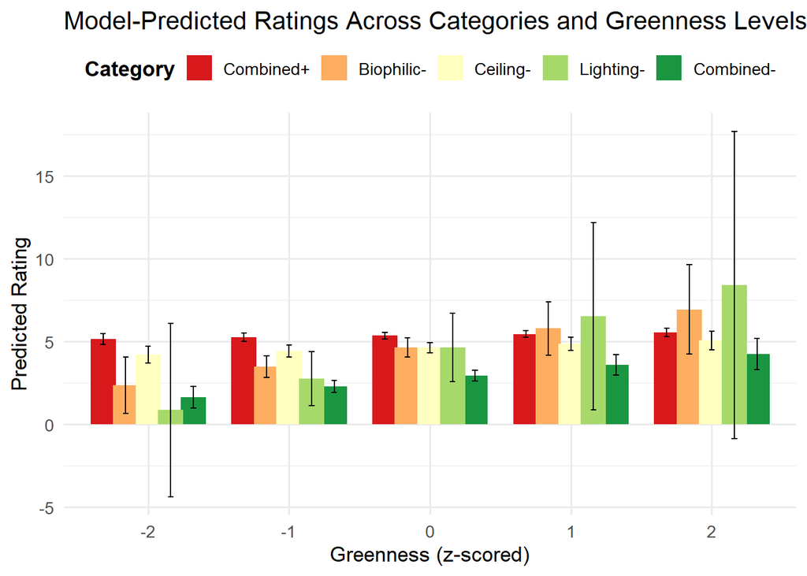

The bar plot presents model-predicted mean ratings at five standardized greenness levels (Greenness_z = −2, −1, 0, +1, +2). Within each greenness level, bars of different colors represent the predicted ratings for each Category, and the error bars indicate 95% confidence intervals. This visualization allows direct comparison of how different categories were rated under the same greenness condition.

[output not shown]

[output not shown]

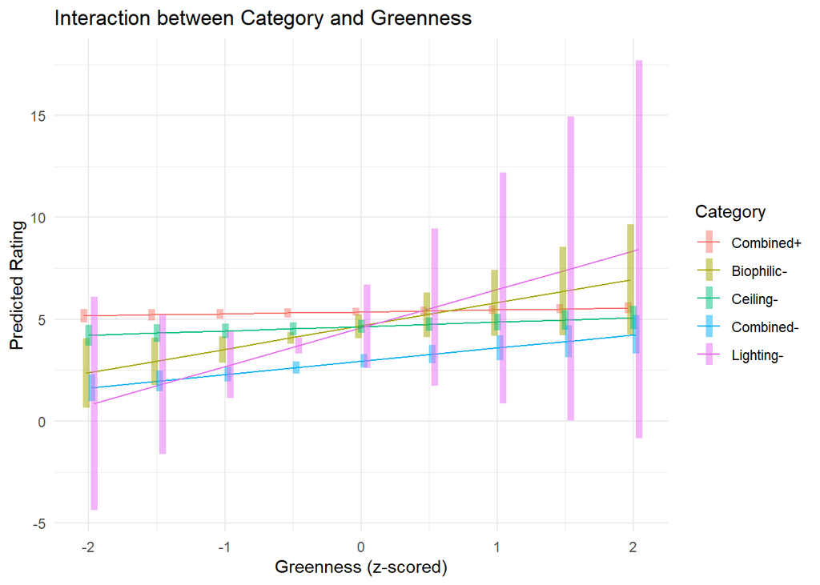

Basically the same content as the previous figure.

## Effect of greenness

### Slopes

To further examine how greenness influenced ratings within each category, we estimated the simple slopes of Greenness_z for every Category. This analysis provides the rate of change in predicted rating as greenness increases, separately for each category. The resulting table lists the estimated slopes, standard errors, and 95% confidence intervals, allowing comparison of the strength and direction of greenness effects across categories.

|  | Category | Slope | Std_Error | DF | CI_lower | CI_upper |
| --- | --- | --- | --- | --- | --- | --- |
| 1 | Combined+ | 0.099 | 0.055 | Inf | -0.008 | 0.207 |
| 2 | Biophilic- | 1.147 | 0.556 | Inf | 0.056 | 2.237 |
| 3 | Ceiling- | 0.215 | 0.116 | Inf | -0.013 | 0.443 |
| 4 | Combined- | 0.651 | 0.190 | Inf | 0.278 | 1.024 |
| 5 | Lighting- | 1.889 | 1.848 | Inf | -1.733 | 5.511 |

### Plot

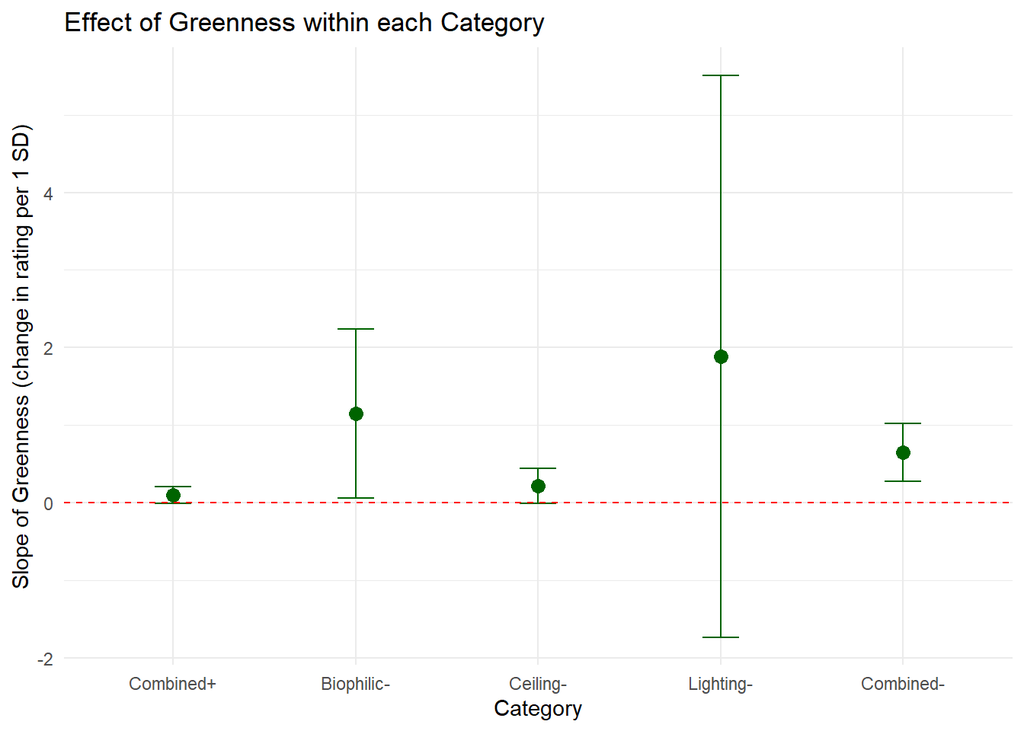

These results suggest that greenness does not exert a uniform influence across categories:

In some conditions (e.g., Combined-, possibly Biophilic-), greenness acts as a meaningful predictor of higher ratings.

In others (e.g., Combined+, Ceiling-, Lighting-), the effect of greenness is weak or too uncertain to be conclusive.

Overall, this pattern supports the idea that the impact of greenness on ratings is context-dependent, rather than consistent across all image types.